## In-class worksheet 7

**Feb 6, 2018** *Yao in the class*

In this worksheet, we will use the libraries tidyverse and nycflights13:

```r
library(tidyverse)
theme_set(theme_bw(base_size=12)) # set default ggplot2 theme
library(nycflights13)
```

The nycflights13 package contains information about all planes departing fron New York City in 2013.

## 1. Joining tables

The following two tables list the population size and area (in sq miles) of three major Texas cities each:

```r
population <- read.csv(text=
"city,year,population
Houston,2014,2239558
San Antonio,2014,1436697
Austin,2014,912791
Austin,2010,790390", stringsAsFactors = FALSE)
population
```

```
##          city year population
## 1     Houston 2014    2239558
## 2 San Antonio 2014    1436697
## 3      Austin 2014     912791
## 4      Austin 2010     790390
```

```r
area <- read.csv(text=
"city,area
Houston,607.5
Dallas,385.6
Austin,307.2", stringsAsFactors = FALSE)
area
```

```
##      city  area
## 1 Houston 607.5
## 2  Dallas 385.6
## 3  Austin 307.2
```

*Note: We can read data from .txt/.csv with “stringsAsFactors = FALSE”.*

Combine these two tables using the functions `left_join()`, `right_join()`, and `inner_join()`. How do these join functions differ in their results?

```r
left_join(population,area) # keep the left data, add variables from the right data
```

```
##          city year population  area
## 1     Houston 2014    2239558 607.5
## 2 San Antonio 2014    1436697    NA
## 3      Austin 2014     912791 307.2
## 4      Austin 2010     790390 307.2
```

```r
right_join(population,area) # keep the right data, add variables from the right data
```

```
##      city year population  area
## 1 Houston 2014    2239558 607.5
## 2  Dallas   NA         NA 385.6
## 3  Austin 2014     912791 307.2
## 4  Austin 2010     790390 307.2
```

```r
inner_join(population,area) # Intersection observations for column 1, all variables
```

```
##      city year population  area
## 1 Houston 2014    2239558 607.5
## 2  Austin 2014     912791 307.2
## 3  Austin 2010     790390 307.2
```

```r
semi_join(population,area) # Intersection observations for column 1, left variables
```

```
##      city year population
## 1 Houston 2014    2239558
## 2  Austin 2014     912791
## 3  Austin 2010     790390
```

```r
full_join(population,area) # All observations, all variables, with NA filled
```

```
##          city year population  area
## 1     Houston 2014    2239558 607.5
## 2 San Antonio 2014    1436697    NA
## 3      Austin 2014     912791 307.2
## 4      Austin 2010     790390 307.2
## 5      Dallas   NA         NA 385.6
```

```r
anti_join(population,area) # observations for column 1 in left but not in right, left variables
```

```
##          city year population
## 1 San Antonio 2014    1436697
```

## 2. Relationship between arrival delay and age of plane

The table `flights` from nycflights13 contains information about individual departures:

```r
flights
```

```
## # A tibble: 336,776 x 19
##     year month   day dep_time sched_dep_time dep_delay arr_time
##    <int> <int> <int>    <int>          <int>     <dbl>    <int>
##  1  2013     1     1      517            515      2.00      830
##  2  2013     1     1      533            529      4.00      850
##  3  2013     1     1      542            540      2.00      923
##  4  2013     1     1      544            545     -1.00     1004
##  5  2013     1     1      554            600     -6.00      812
##  6  2013     1     1      554            558     -4.00      740
##  7  2013     1     1      555            600     -5.00      913
##  8  2013     1     1      557            600     -3.00      709
##  9  2013     1     1      557            600     -3.00      838
## 10  2013     1     1      558            600     -2.00      753
## # ... with 336,766 more rows, and 12 more variables: sched_arr_time <int>,
## #   arr_delay <dbl>, carrier <chr>, flight <int>, tailnum <chr>,
## #   origin <chr>, dest <chr>, air_time <dbl>, distance <dbl>, hour <dbl>,
## #   minute <dbl>, time_hour <dttm>
```

Individual planes are indicated by their tail number (`tailnum` in the table). Calculate the mean arrival delay (`arr_delay`) for each tail number. Do you notice anything unusual in the result? Try to calculate the mean with and without adding the option `na.rm=TRUE`.

```r
flights %>% group_by(tailnum) %>% summarize(mean_arrival_delay = mean(arr_delay))
```

```
## # A tibble: 4,044 x 2
##    tailnum mean_arrival_delay
##    <chr>                <dbl>
##  1 D942DN              31.5
##  2 N0EGMQ              NA
##  3 N10156              NA
##  4 N102UW               2.94
##  5 N103US             - 6.93
##  6 N104UW              NA
##  7 N10575              NA
##  8 N105UW             - 0.267
##  9 N107US             - 5.73
## 10 N108UW             - 1.25
## # ... with 4,034 more rows
```

```r
flights %>% group_by(tailnum) %>% summarize(mean_arrival_delay = mean(arr_delay,na.rm=TRUE)) -> MeanArrivalDelay# a logical value indicating whether NA values should be stripped before the computation proceeds.
```

Information about individual planes is availabe in the table `planes`:

```r
planes
```

```
## # A tibble: 3,322 x 9
##    tailnum  year type      manufacturer  model  engines seats speed engine
##    <chr>   <int> <chr>     <chr>         <chr>    <int> <int> <int> <chr>
##  1 N10156   2004 Fixed wi… EMBRAER       EMB-1…       2    55    NA Turbo…
##  2 N102UW   1998 Fixed wi… AIRBUS INDUS… A320-…       2   182    NA Turbo…
##  3 N103US   1999 Fixed wi… AIRBUS INDUS… A320-…       2   182    NA Turbo…
##  4 N104UW   1999 Fixed wi… AIRBUS INDUS… A320-…       2   182    NA Turbo…
##  5 N10575   2002 Fixed wi… EMBRAER       EMB-1…       2    55    NA Turbo…
##  6 N105UW   1999 Fixed wi… AIRBUS INDUS… A320-…       2   182    NA Turbo…
##  7 N107US   1999 Fixed wi… AIRBUS INDUS… A320-…       2   182    NA Turbo…
##  8 N108UW   1999 Fixed wi… AIRBUS INDUS… A320-…       2   182    NA Turbo…
##  9 N109UW   1999 Fixed wi… AIRBUS INDUS… A320-…       2   182    NA Turbo…
## 10 N110UW   1999 Fixed wi… AIRBUS INDUS… A320-…       2   182    NA Turbo…
## # ... with 3,312 more rows
```

In particular, this table lists the year each individual plane was manufactured. Make a combined table that holds tail number, mean arrival delay, and year of manufacture for each plane. Then plot mean arrival delay vs. year of manufacture.

```r
full_join(MeanArrivalDelay,planes) %>% select(tailnum,mean_arrival_delay,year) -> temp
# left_join(MeanArrivalDelay,planes) %>% select(tailnum,mean_arrival_delay,year) -> temp
temp
```

```
## # A tibble: 4,044 x 3
##    tailnum mean_arrival_delay  year
##    <chr>                <dbl> <int>
##  1 D942DN              31.5      NA
##  2 N0EGMQ               9.98     NA
##  3 N10156              12.7    2004
##  4 N102UW               2.94   1998
##  5 N103US             - 6.93   1999
##  6 N104UW               1.80   1999
##  7 N10575              20.7    2002
##  8 N105UW             - 0.267  1999
##  9 N107US             - 5.73   1999
## 10 N108UW             - 1.25   1999
## # ... with 4,034 more rows
```

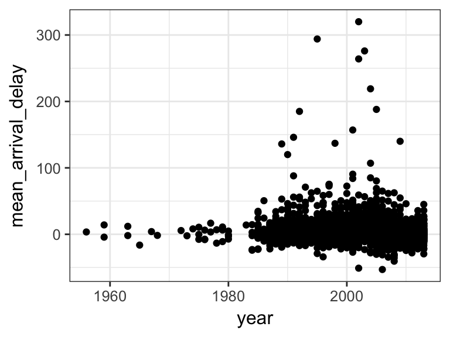

```r
ggplot(temp,aes(y = mean_arrival_delay,x = year)) + geom_point()
```

## 3. Relationship between arrival delay and temperature

Now calculate the mean arrival delay for each day of the year, and store in a variable called `daily_delays`.

```r
flights %>% group_by(year,month,day) %>% summarize(mean_arrival_delay = mean(arr_delay,na.rm=TRUE)) -> daily_delays
daily_delays
```

```
## # A tibble: 365 x 4
## # Groups:   year, month [?]
##     year month   day mean_arrival_delay
##    <int> <int> <int>              <dbl>
##  1  2013     1     1             12.7
##  2  2013     1     2             12.7
##  3  2013     1     3              5.73
##  4  2013     1     4            - 1.93
##  5  2013     1     5            - 1.53
##  6  2013     1     6              4.24
##  7  2013     1     7            - 4.95
##  8  2013     1     8            - 3.23
##  9  2013     1     9            - 0.264
## 10  2013     1    10            - 5.90
## # ... with 355 more rows
```

We want to correlate these delay values with the temperature of each day. The data frame `weather` holds temperature measurements for each hour of each day:

```r
weather
```

```
## # A tibble: 26,130 x 15
##    origin  year month   day  hour  temp  dewp humid wind_dir wind_speed
##    <chr>  <dbl> <dbl> <int> <int> <dbl> <dbl> <dbl>    <dbl>      <dbl>
##  1 EWR     2013  1.00     1     0  37.0  21.9  54.0      230      10.4
##  2 EWR     2013  1.00     1     1  37.0  21.9  54.0      230      13.8
##  3 EWR     2013  1.00     1     2  37.9  21.9  52.1      230      12.7
##  4 EWR     2013  1.00     1     3  37.9  23.0  54.5      230      13.8
##  5 EWR     2013  1.00     1     4  37.9  24.1  57.0      240      15.0
##  6 EWR     2013  1.00     1     6  39.0  26.1  59.4      270      10.4
##  7 EWR     2013  1.00     1     7  39.0  27.0  61.6      250       8.06
##  8 EWR     2013  1.00     1     8  39.0  28.0  64.4      240      11.5
##  9 EWR     2013  1.00     1     9  39.9  28.0  62.2      250      12.7
## 10 EWR     2013  1.00     1    10  39.0  28.0  64.4      260      12.7
## # ... with 26,120 more rows, and 5 more variables: wind_gust <dbl>,
## #   precip <dbl>, pressure <dbl>, visib <dbl>, time_hour <dttm>
```

First, calculate the mean temperature for each day, and store in a variable called `mean_temp`:

```r
weather %>% group_by(year,month,day) %>% summarize(mean_temp = mean(temp)) -> mean_temp
mean_temp
```

```
## # A tibble: 364 x 4
## # Groups:   year, month [?]
##     year month   day mean_temp
##    <dbl> <dbl> <int>     <dbl>
##  1  2013  1.00     1      38.9
##  2  2013  1.00     2      28.7
##  3  2013  1.00     3      29.6
##  4  2013  1.00     4      34.3
##  5  2013  1.00     5      37.1
##  6  2013  1.00     6      38.4
##  7  2013  1.00     7      41.8
##  8  2013  1.00     8      39.5
##  9  2013  1.00     9      41.8
## 10  2013  1.00    10      45.0
## # ... with 354 more rows
```

Now combine the mean delay and the mean temperature into one table, and then plot mean delay vs. mean temperature.

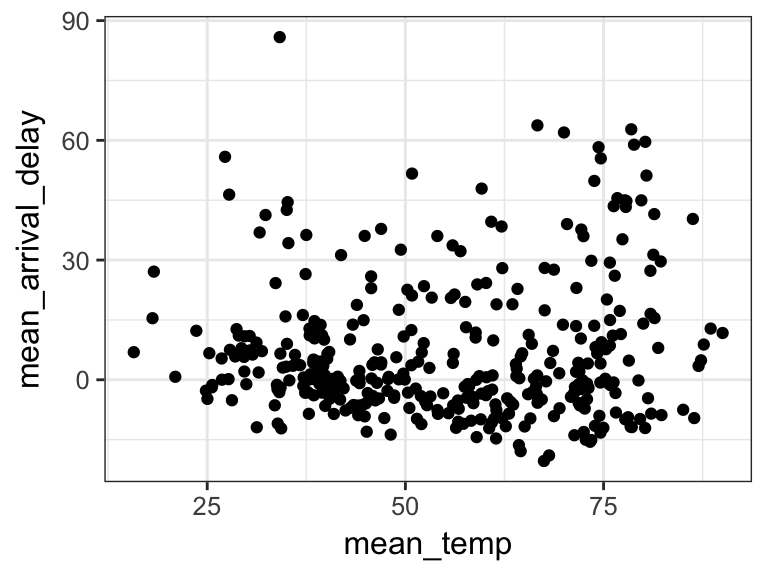

```r
full_join(daily_delays,mean_temp) %>% ggplot(aes(y = mean_arrival_delay,x = mean_temp)) + geom_point()
```

## 4. If this was easy

Find out for how many tail numbers in the `flights` data set we have no information in the `planes` data set. What do we have to pay attention to when joining the `flights` and `planes` tables?

```r
left_join(flights,planes) -> joined_data
flights %>% left_join(planes, by='tailnum') %>% filter(is.na(type)) %>% tally()
```

```
## # A tibble: 1 x 1
##       n
##   <int>
## 1 52606
```

*There are 52606 such flights. It is important here to tell the left_join() function to join by tailnum, otherwise it tries to join by tailnum and year, but year has different meanings in the two tables.*

Calculate the mean arrival delay by plane model and by plane engine. Sort in order of descending mean delay. Remove all tailnumbers for which no plane information is available.

```r
# 1. plane model
# we first join the fligths table and the planes table to make a new table holding plane model, engine, and arrival delay
flights %>% left_join(planes, by='tailnum') %>%
  filter(!is.na(type)) %>%
  select(model, engine, arr_delay) -> delay_table
delay_table
```

```
## # A tibble: 284,170 x 3
##    model       engine    arr_delay
##    <chr>       <chr>         <dbl>
##  1 737-824     Turbo-fan     11.0
##  2 737-824     Turbo-fan     20.0
##  3 757-223     Turbo-fan     33.0
##  4 A320-232    Turbo-fan    -18.0
##  5 757-232     Turbo-fan    -25.0
##  6 737-924ER   Turbo-fan     12.0
##  7 A320-232    Turbo-fan     19.0
##  8 CL-600-2B19 Turbo-fan    -14.0
##  9 A320-232    Turbo-fan    - 8.00
## 10 A320-232    Turbo-fan    - 2.00
## # ... with 284,160 more rows
```

```r
# we next calculate the mean delay per model
delay_table %>% group_by(model) %>%
  summarize(mean_delay=mean(arr_delay, na.rm=T)) %>%
  arrange(desc(mean_delay)) -> model_delay
model_delay
```

```
## # A tibble: 127 x 2
##    model    mean_delay
##    <chr>         <dbl>
##  1 747-451       120
##  2 757-351        72.5
##  3 A330-223       46.5
##  4 G-IV           41.2
##  5 777-224        40.8
##  6 A319-115       33.5
##  7 A109E          30.6
##  8 A340-313       29.8
##  9 MD-90-30       28.5
## 10 737-76N        28.4
## # ... with 117 more rows
```

```r
# 2. plane engine
# we go back to the delay_table we created above, and now calculate the mean per engine
delay_table %>% group_by(engine) %>%
  summarize(mean_delay=mean(arr_delay, na.rm=T)) %>%
  arrange(desc(mean_delay)) -> engine_delay
engine_delay
```

```
## # A tibble: 6 x 2
##   engine        mean_delay
##   <chr>              <dbl>
## 1 4 Cycle             9.72
## 2 Turbo-shaft         9.28
## 3 Turbo-fan           7.72
## 4 Reciprocating       5.72
## 5 Turbo-prop          4.89
## 6 Turbo-jet           3.19
```